# Final Project

## Time Series

We will be analysing a time series based on the database of food inspections in the city of chicago.  
The data set is in the file “food-inspections.csv”. As it is not originaly a time series, we need to, after loading it, transform the data into a time series.

```r
#libraries required
library(astsa)
library(zoo)
library(ggplot2)
library(forecast)
library(lubridate)
library(readr)
library(tseries)
#load database from file
food_inspections <- read_csv("C:/Users/zé/Desktop/programação/R/STP/Final Work/food-inspections.csv")

#get data on the dates and the results of inspections
inspectionDateTable = food_inspections["Inspection Date"]
resultsTable = food_inspections["Results"]

#preprocessing of data
resultsList = unlist(resultsTable)
inspectionDateList = as.Date(unlist(inspectionDateTable)/(24*60*60))
resultsFilterList = ifelse(resultsList == "Pass",1,ifelse(resultsList == "Fail",1,1))
inspectionMatrix = matrix(c(inspectionDateList,resultsFilterList),nrow = length(inspectionDateList),ncol = 2)
inspectionMatrixFilter = inspectionMatrix[inspectionMatrix[,2]==1,]

#aggregate inspections by month and turn it into a time series
inspectionMatrixByMonth = aggregate(inspectionMatrixFilter[,2],by=list(year(as.Date(inspectionMatrixFilter[,1]))*12+month(as.Date(inspectionMatrixFilter[,1]))),FUN=sum)
inspectionTS = ts(inspectionMatrixByMonth[,2],start = c(2010,1),end = c(2019,9),frequency = 12)
```

The series is updated every day, as such the last month is not complete and was removed.  
There is a know break in the data wich occured in the start of 2018 due to policy change.

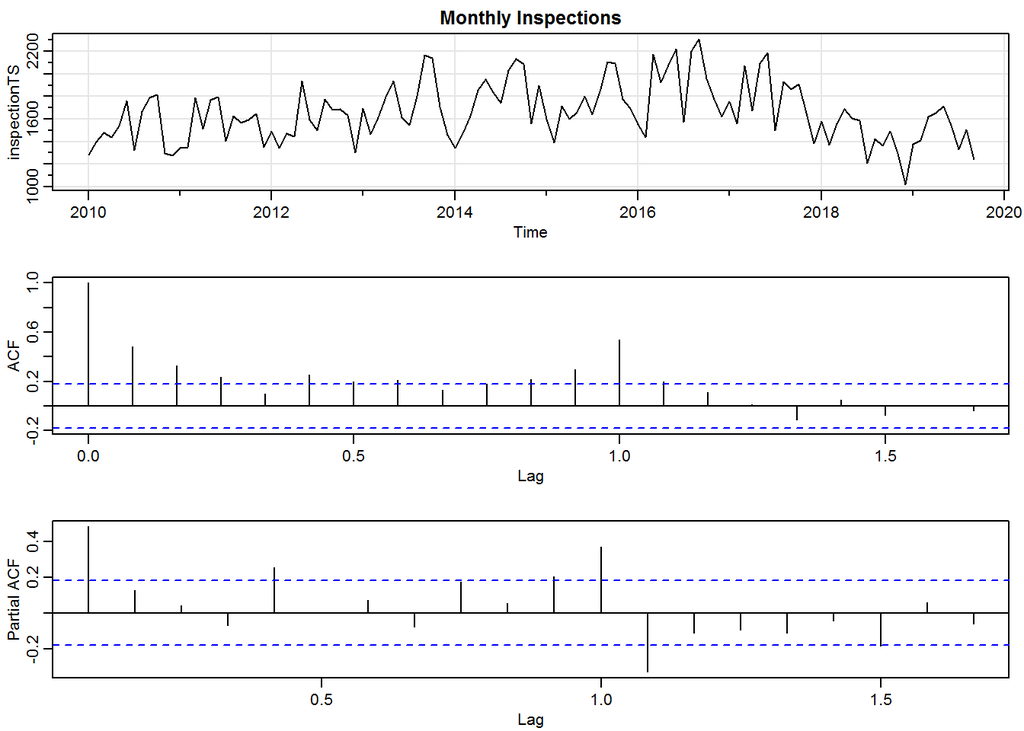

```r
par(mfrow=c(3,1))
tsplot(inspectionTS,main="Monthly Inspections")
acf(inspectionTS)
pacf(inspectionTS)
```

## Transformations and Differencing

We can easly spot the break in the data at the previously mentioned location.  
As we are dealing with monthly data we will ajust the data to the number of days  
in a month and see if it improves.

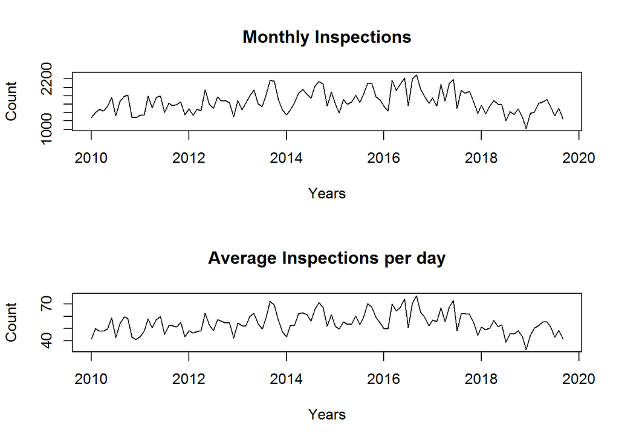

```r
monthdays = rep(c(31,28,31,30,31,30,31,31,30,31,30,31),10)
monthdays[26 + (4*12)*(0:1)] = 29
monthdays=monthdays[0:117]
AvgInspectionTS = inspectionTS/monthdays
par(mfrow=c(2,1))
plot(inspectionTS, main="Monthly Inspections",
  ylab="Count",xlab="Years")
plot(AvgInspectionTS, main="Average Inspections per day",
  ylab="Count", xlab="Years")
```

We can see that the plot is almost the same, as such the transformtaion was not usefull  
and will not be kept.

There are no obvious changes in the variability of the data throughout time. Therefore  
we will not be performing a box-cox transformation.

From the ACF we can conclude that the data has a 1 year(12 month) seasonal component. As  
such seasonal differencing will be performed.

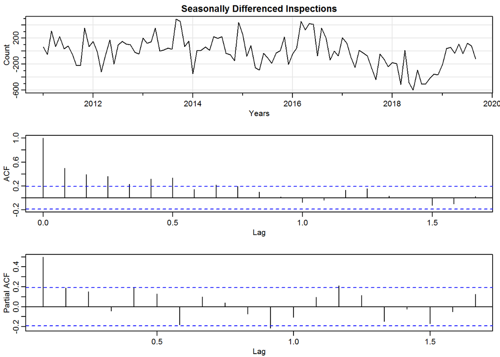

```r
sDiffInspectionTs = diff(inspectionTS,lag=12)
par(mfrow=c(3,1))
tsplot(sDiffInspectionTs,main="Seasonally Differenced Inspections",
  ylab="Count", xlab="Years")
acf(sDiffInspectionTs,main="Seasonally Differenced Inspections ACF")
pacf(sDiffInspectionTs,main="Seasonally Differenced Inspections PACF")
```

At this point seasonality is no longer detected. It is not clear if we need to perform  
regular differencing, as such we will use a Kwiatkowski-Phillips-Schmidt-Shin (KPSS) test,  
a test for the stationarity of a time series.

```r
kpss.test(sDiffInspectionTs)
```

```
##
##  KPSS Test for Level Stationarity
##
## data:  sDiffInspectionTs
## KPSS Level = 0.65671, Truncation lag parameter = 4, p-value =
## 0.01748
```

As the p-value is quite small (0.01748) we can reject the null hypotheses, that the data is  
stationary. As such we will perform differencing.

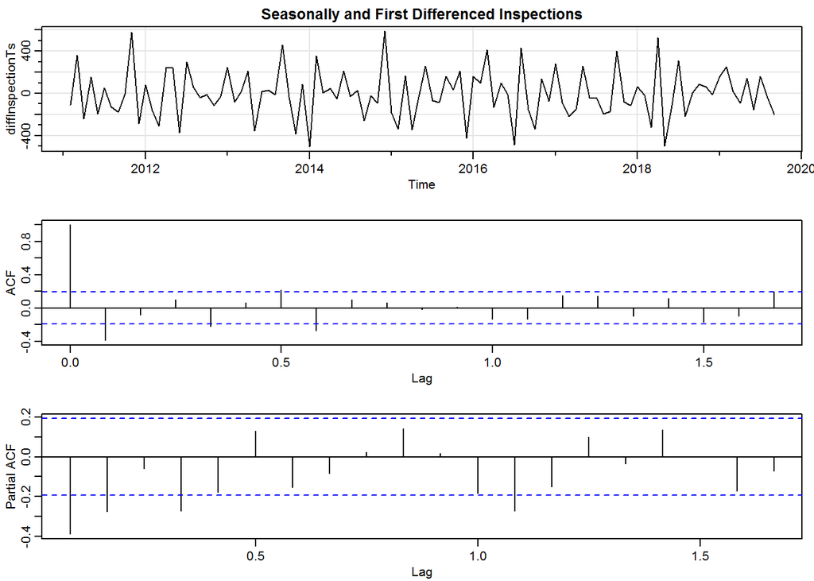

```r
diffInspectionTs = diff(sDiffInspectionTs)
par(mfrow=c(3,1))
tsplot(diffInspectionTs,main="Seasonally and First Differenced Inspections")
acf(diffInspectionTs)
pacf(diffInspectionTs)
```

At this point the series looks stationary, however lets perform a second KPSS test to confirm.

```r
kpss.test(diffInspectionTs)
```

```
##
##  KPSS Test for Level Stationarity
##
## data:  diffInspectionTs
## KPSS Level = 0.031329, Truncation lag parameter = 4, p-value = 0.1
```

We can see that the p-value is now above the tipical confidence level of 0.05, and as such  
we will assume that the data is stationary.

## Modeling

Given that we now know the required differencing to make the series stationary, we will perform  
modeling.  
We will try to obtain to models from distinct families of models.  
The first one is an sarima model.  
The second one will be an exponential smothing model.

But first we will divide the data into a train and test set.

```r
inspectionsTrain = window(inspectionTS, end=c(2018,9))
inspectionsTest = window(inspectionTS, start=c(2018,10))
```

## Sarima Models

We have previously determined that one differencing is required both for the seasonal component  
and for the autoregressive component

For seasonality we will try (0,0),(0,1),(0,2),(1,0),(1,1),(1,2),(2,0),(2,1),(2,2), while  
seting the arma to (0,0).

```r
fit = Arima(inspectionsTrain, order=c(0,1,0), seasonal=c(0,1,0))
fit$bic
```

```
## [1] 1275.46
```

```r
fit = Arima(inspectionsTrain, order=c(0,1,0), seasonal=c(0,1,1))
fit$bic
```

```
## [1] 1265.344
```

```r
fit = Arima(inspectionsTrain, order=c(0,1,0), seasonal=c(0,1,2))
fit$bic
```

```
## [1] 1259.02
```

```r
fit = Arima(inspectionsTrain, order=c(0,1,0), seasonal=c(1,1,0))
fit$bic
```

```
## [1] 1277.936
```

```r
fit = Arima(inspectionsTrain, order=c(0,1,0), seasonal=c(1,1,1))
fit$bic
```

```
## [1] 1261.982
```

```r
fit = Arima(inspectionsTrain, order=c(0,1,0), seasonal=c(1,1,2))
fit$bic
```

```
## [1] 1263.541
```

```r
fit = Arima(inspectionsTrain, order=c(0,1,0), seasonal=c(2,1,0))
fit$bic
```

```
## [1] 1274.332
```

```r
fit = Arima(inspectionsTrain, order=c(0,1,0), seasonal=c(2,1,1))
fit$bic
```

```
## [1] 1258.966
```

```r
fit = Arima(inspectionsTrain, order=c(0,1,0), seasonal=c(2,1,2))
fit$bic
```

```
## [1] 1259.112
```

The best(minimum) BIC was the one from the (2,1) model, as such we will proced with that seasonality.

Now we will select the arma model, from the ACF we predict an arma(2,1), so we will try values  
around that.

The values tested will be (1,0),(1,1),(1,2),(2,0),(2,1),(2,2),(3,0),(3,1),(3,2), while keeping  
the seasonal values as (2,1).

```r
fit = Arima(inspectionsTrain, order=c(1,1,0), seasonal=c(2,1,1))
fit$bic
```

```
## [1] 1248.037
```

```r
fit = Arima(inspectionsTrain, order=c(1,1,1), seasonal=c(2,1,1))
fit$bic
```

```
## [1] 1239.98
```

```r
fit = Arima(inspectionsTrain, order=c(1,1,2), seasonal=c(2,1,1))
fit$bic
```

```
## [1] 1243.801
```

```r
fit = Arima(inspectionsTrain, order=c(2,1,0), seasonal=c(2,1,1))
fit$bic
```

```
## [1] 1243.123
```

```r
fit = Arima(inspectionsTrain, order=c(2,1,1), seasonal=c(2,1,1))
fit$bic
```

```
## [1] 1244.438
```

```r
fit = Arima(inspectionsTrain, order=c(3,1,1), seasonal=c(2,1,1))
fit$bic
```

```
## [1] 1252.166
```

The (2,2),(3,0) and (3,2) created an optimization error, and as such have been discarded.

The best model was the Sarima(1,1,1,2,1,1)12, as such now we will show the fitted  
model and the ACF and PACF of the residuals.

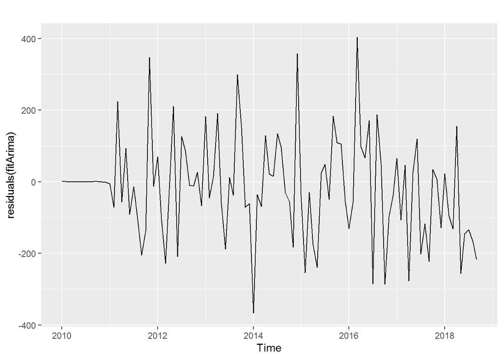

```r
fitArima = Arima(inspectionsTrain, order=c(1,1,1), seasonal=c(2,1,1))

autoplot(residuals(fitArima))
```

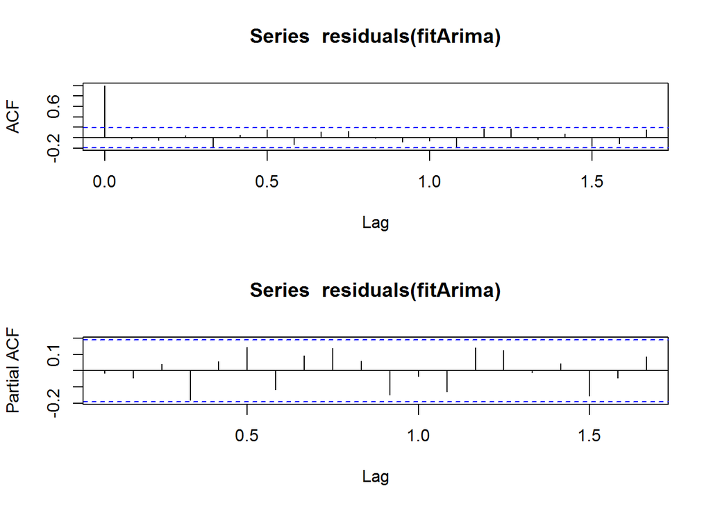

```r
par(mfrow=c(2,1))
acf(residuals(fitArima))
pacf(residuals(fitArima))
```

```r
Box.test(resid(fitArima))
```

```
##
##  Box-Pierce test
##
## data:  resid(fitArima)
## X-squared = 0.028811, df = 1, p-value = 0.8652
```

The residuals seem like white noise and both ACF and PACF confirm this, as well as  
the box-pierce test.  
Now that we have our hand picked Sarima model, lets also use an automated method  
to pick a model. We will use auto.arima.

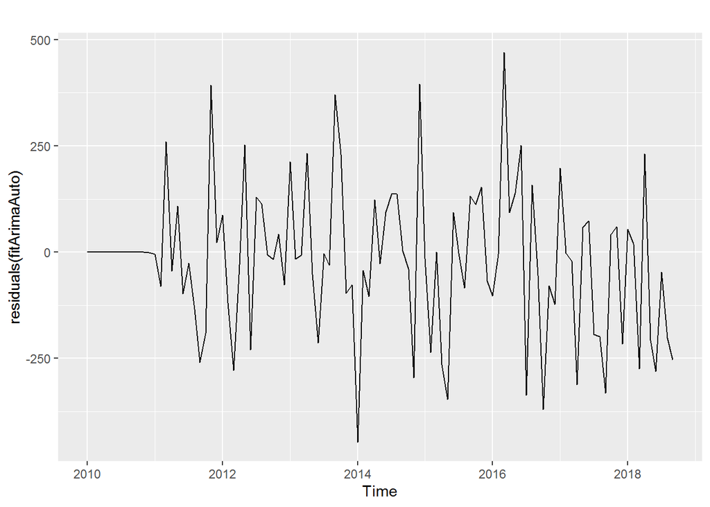

```r
fitArimaAuto = auto.arima(inspectionsTrain)

autoplot(residuals(fitArimaAuto))
```

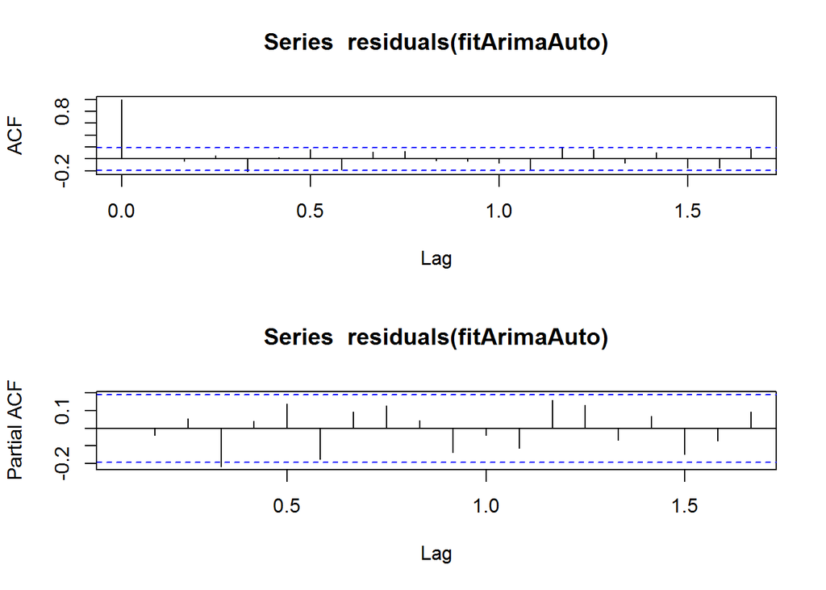

```r
par(mfrow=c(2,1))
acf(residuals(fitArimaAuto))
pacf(residuals(fitArimaAuto))
```

```r
Box.test(resid(fitArimaAuto))
```

```
##
##  Box-Pierce test
##
## data:  resid(fitArimaAuto)
## X-squared = 0.0010824, df = 1, p-value = 0.9738
```

Once again all the plots and tests indicate that the residuals are white noise.  
As such now we will procede with modeling for the next type of model.

## Exponential Smothing

Exponential smoothing designates a set of methods for forecasting that are  
essentially non parametric in the sense that you do not find a model for the  
data and iterate the model to obtain forecasts. Also these methods do not require  
assumptions such as stationarity, Gaussianity, etc. The forecasts are computed from  
the data with weights that decay exponentially.

The basic formula for the predictions is:  
y^T+1|T = αyT + α(1 − α)yT−1 + α(1 − α)^2yT−2 + ⋯

A lot of variations exist, including those with seasonal components and trend components  
For these 2 more parameters must be selected or estimated, gamma and beta, for seasonal and  
trend, respectively.

## Exponential Smothing Aplication

We have had no practice in class about how to pick the ES models by hand, as such all models  
will be automaticaly selected.

For this work we will use the ets function, wich has both trend and seasonal components.  
It also automaticaly selects the best parameters based on the data.

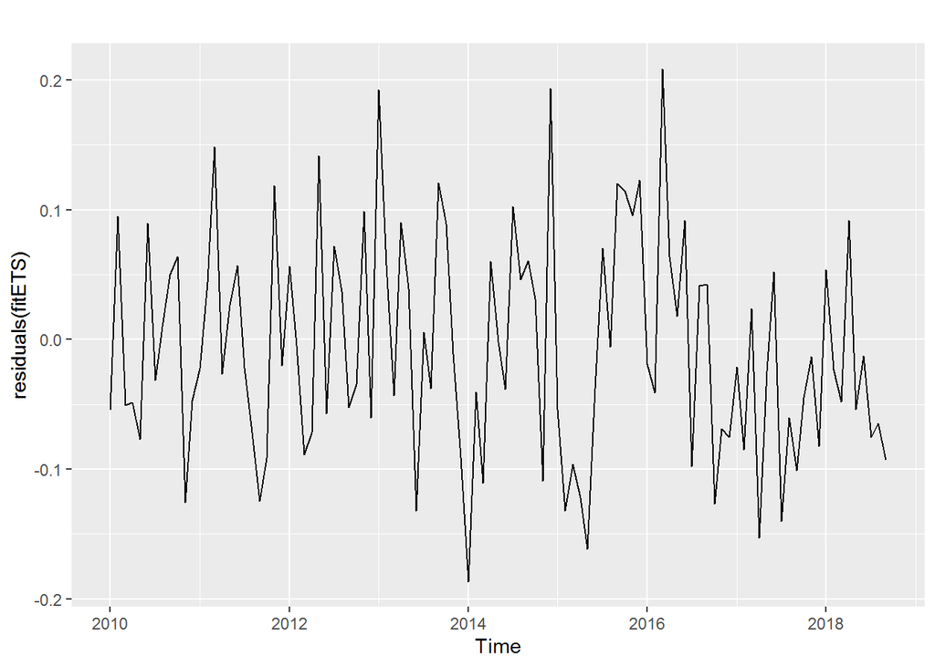

```r
fitETS <- ets(inspectionsTrain)

autoplot(residuals(fitETS))
```

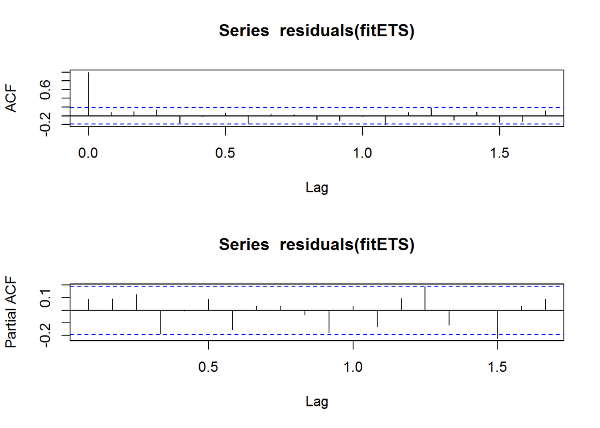

```r
par(mfrow=c(2,1))
acf(residuals(fitETS))
pacf(residuals(fitETS))
```

```r
Box.test(resid(fitETS))
```

```
##
##  Box-Pierce test
##
## data:  resid(fitETS)
## X-squared = 0.81668, df = 1, p-value = 0.3662
```

The residuals seem like white noise and both ACF and PACF confirm this, as well as  
the box-pierce test.

After some deliberation and a discution with the teacher, brought by the bad forecasting  
results(shown later), another hand picked exponential smothing model will be tested.

The ets function will still be used, but this time the model will not be automacially  
selected. The model will be an (A,A,A), with all aditive components

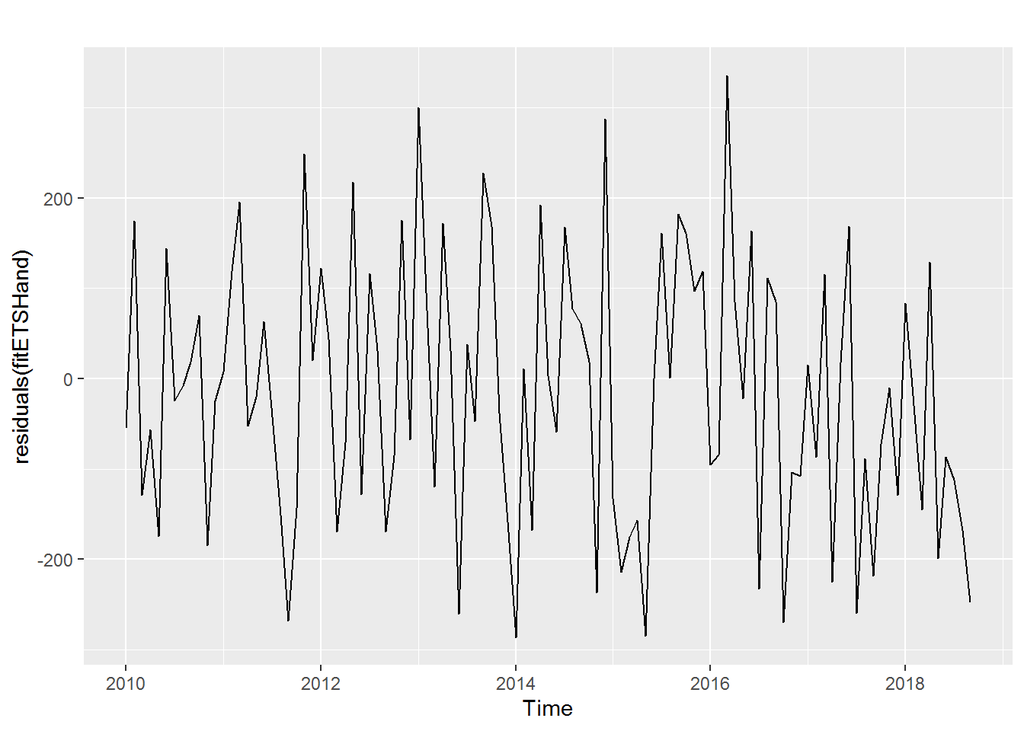

```r
fitETSHand <- ets(inspectionsTrain,model="AAA")

autoplot(residuals(fitETSHand))
```

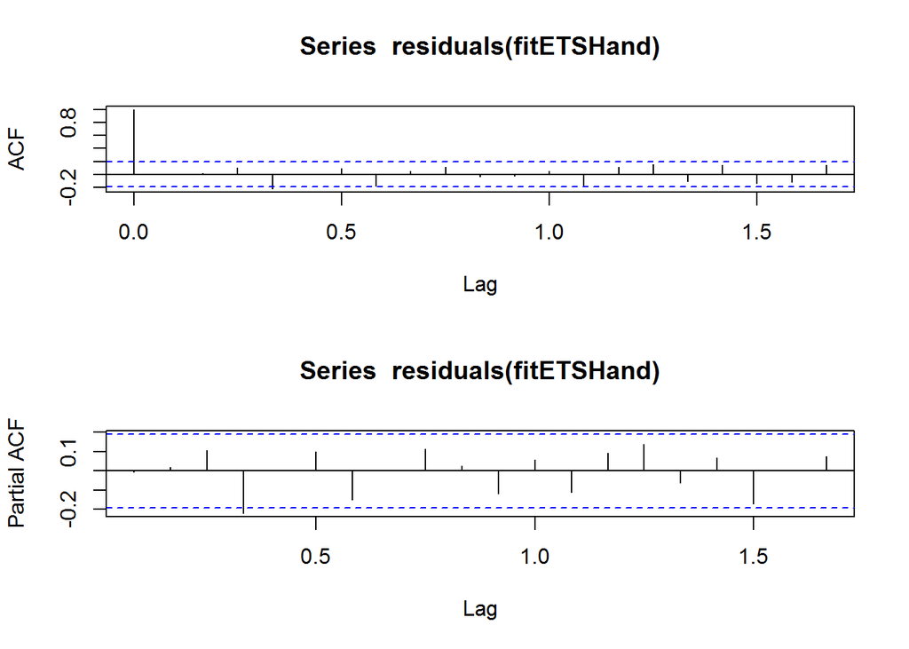

```r
par(mfrow=c(2,1))
acf(residuals(fitETSHand))
pacf(residuals(fitETSHand))
```

```r
Box.test(resid(fitETSHand))
```

```
##
##  Box-Pierce test
##
## data:  resid(fitETSHand)
## X-squared = 0.0037095, df = 1, p-value = 0.9514
```

The residuals seem like white noise and both ACF and PACF confirm this, as well as  
the box-pierce test.

## Forecasting

We will show the time series in black and both the fitted model and predictions in blue.  
The forecast interval will be the last year.

### Hand picked sarima models

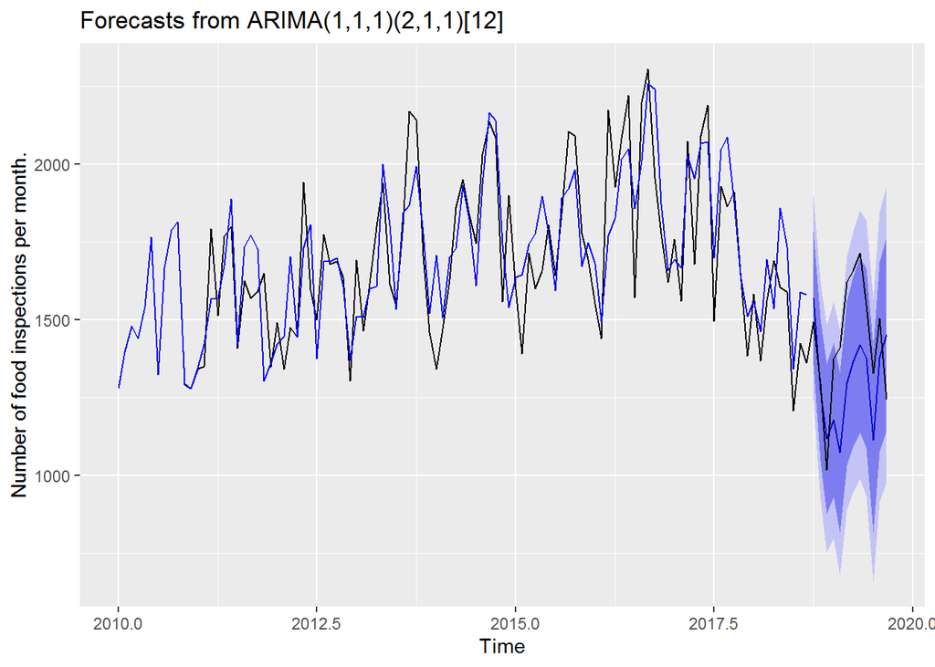

```r
autoplot(forecast(fitArima,h=12)) +
  autolayer(inspectionTS, series="Real series",color = "black") +
  autolayer(fitArima$fitted, series="Fitted series",color = "blue") +
ylab("Number of food inspections per month.")
```

The obtained forecasts seems perfectly reasonable, with most values inside the 95% band.  
However it would seem that due to the variance of the process the predicted(most likely) values  
are quite far from the real ones.

### Automatically selected Sarima model

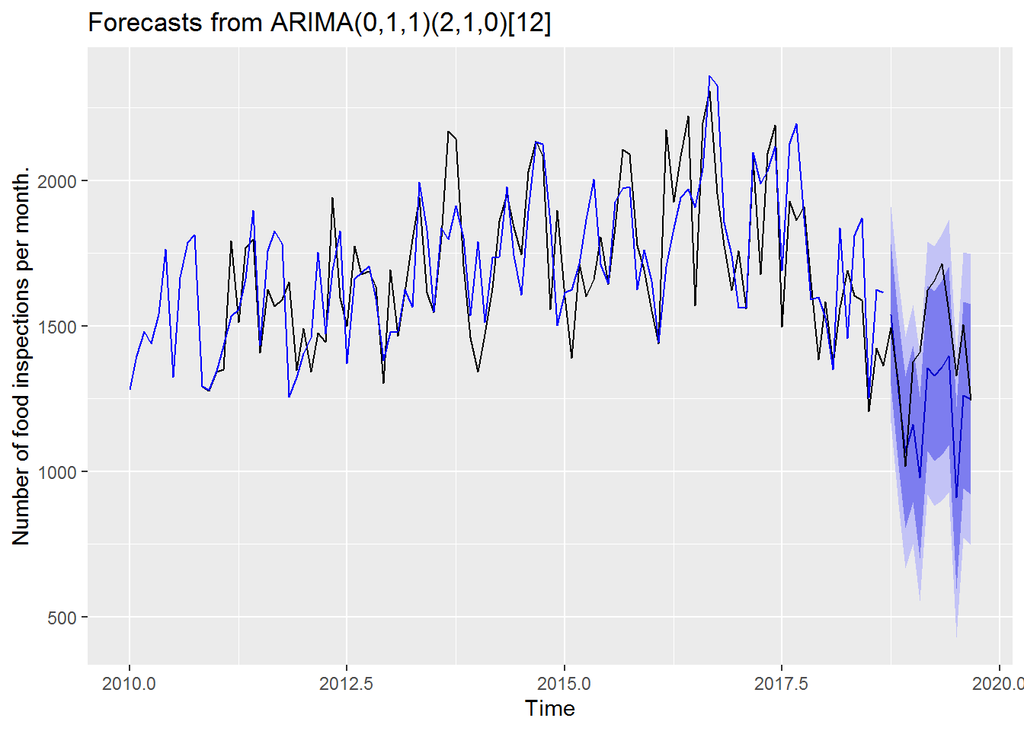

```r
autoplot(forecast(fitArimaAuto,h=12)) +
  autolayer(inspectionTS, series="Real series",color = "black") +
  autolayer(fitArimaAuto$fitted, series="Fitted series",color = "blue") +
ylab("Number of food inspections per month.")
```

The same can be said about this model as the previous one, however the forecast seems just slightly worse.  
The difference is still small enough that further analisys will be performd to pick bettwen the 2.

### Automatically selected Esponential smothing model

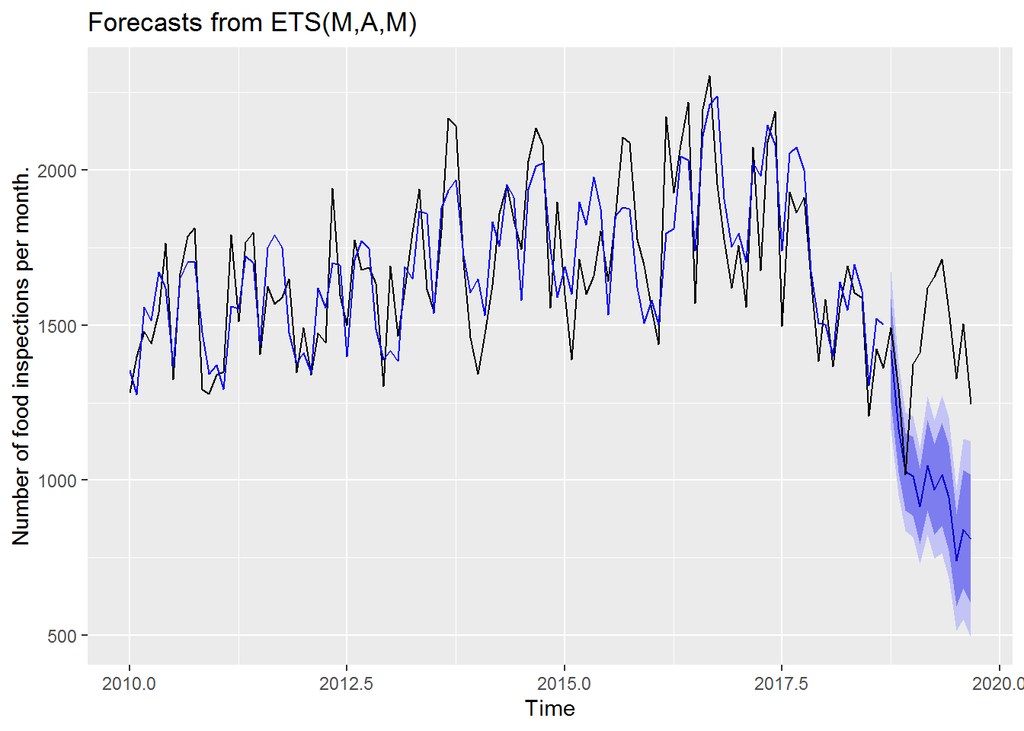

```r
autoplot(forecast(fitETS,h=12)) +
  autolayer(inspectionTS, series="Real series",color = "black") +
  autolayer(fitETS$fitted, series="Fitted series",color = "blue") +
ylab("Number of food inspections per month.")
```

As we can see, the fit seems quite good, however the predictions are poor, with most values not even  
laying on the bands of confidence. This may be due to the nature of the problem, as there is the  
previously mentioned change in the data.

Since the forecasts are so poor lets show the acf to see if we managed to use all the information.

[figure not shown]

```r
acf(resid(fitArimaAuto))
```

```r
Box.test(resid(fitArimaAuto))
```

[output not shown]

The box test gives a high p-value, so we conclude the values are not correlated  
and as such we can now conclude that the residuals are white noise.

### Hand Picked Esponential smothing model

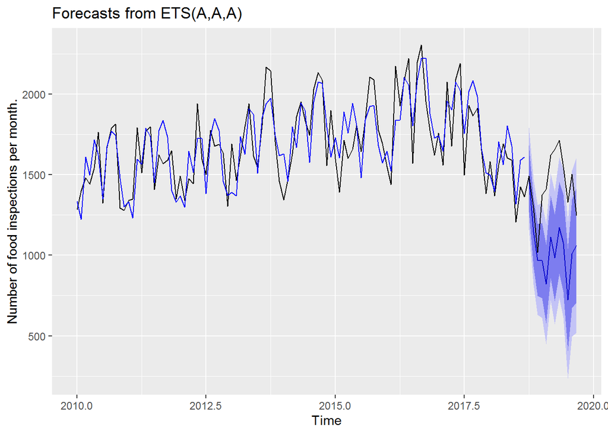

```r
autoplot(forecast(fitETSHand,h=12)) +
  autolayer(inspectionTS, series="Real series",color = "black") +
  autolayer(fitETSHand$fitted, series="Fitted series",color = "blue") +
ylab("Number of food inspections per month.")
```

The prediction obtained by the hand selected exponential smothing model are better than those from the automatically selected model, however, they are still quite poor, with most values not even  
laying on the bands of confidence. This may be due to the nature of the problem, as there is the  
previously mentioned change in the data.

Since the forecasts are so poor lets show the acf to see if we managed to use all the information.

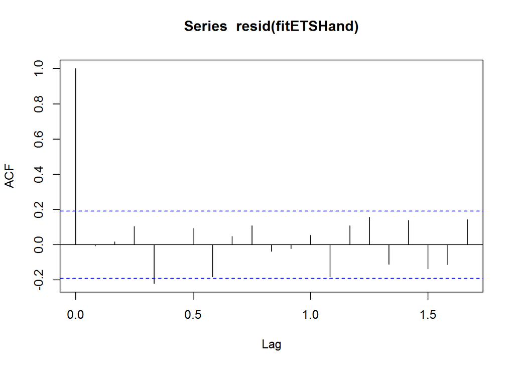

```r
acf(resid(fitETSHand))
```

The acf only shows one value outside the confidence bands, so it seems we fitted the data correctly.  
However just to be sure lets do a box test.

```r
Box.test(resid(fitETSHand))
```

```
##
##  Box-Pierce test
##
## data:  resid(fitETSHand)
## X-squared = 0.0037095, df = 1, p-value = 0.9514
```

The box test gives a high p-value, so we conclude the values are not correlated  
and as such we can now conclude that the residuals are white noise.

Given that the data was fitted correctly but the forecasts are poor for both the models  
we come to the conclusion that the exponential smothing model is not good for this data.

## Result analizys

```r
accuracy(forecast(fitArima,h=12), inspectionsTest)
```

```
##                     ME     RMSE      MAE       MPE      MAPE      MASE
## Training set -16.55065 143.2789 106.4325 -1.583077  6.320268 0.5987672
## Test set     132.79895 220.0403 196.6586  8.217266 13.477107 1.1063610
##                     ACF1 Theil's U
## Training set -0.01656484        NA
## Test set      0.42002346 0.9828694
```

```r
accuracy(forecast(fitArimaAuto,h=12), inspectionsTest)
```

```
##                     ME     RMSE      MAE       MPE      MAPE      MASE
## Training set -19.00285 174.3333 127.2715 -1.764236  7.520156 0.7160034
## Test set     194.33362 257.9913 210.7274 12.844302 14.201953 1.1855089
##                     ACF1 Theil's U
## Training set 0.003210647        NA
## Test set     0.332716386  1.150284
```

As we can see the errors in the test set for the hand picked model is smaller that for the one automatically selected.  
Therefore the final and best model is the Sarima(1,1,1)(2,1,1)12.

The question of usefullness of the model still persists.The forecasts are quite good and even with the change of the  
series in 2018 we manage to capture the change, however the real values stay within the 95% bands but far away from  
the predicted values, wich means that we have to take in consideration the entire band.  
That is a problem, from 2010 to 2018 the mean remained mostly unchanged, with only variability around it.  
The bands are almost as wide as said variability, as such were we to use such large confidence bands in  
that section, the predictions would be about as good as using the mean.

## Conclusion

We managed to capture the series and obtain good forecasts, however there are some concerns of usability.  
If in the future the mean stabilizes, much like on the past, and the variance of the model does not reduce  
then the model is not usefull, on the other hand if either of those proves untrue, while the forecasts remain  
good, then the model is a usefull one.